# DATA2x02 Assignment

# 2 Data cleaning

## 2.1 Gender

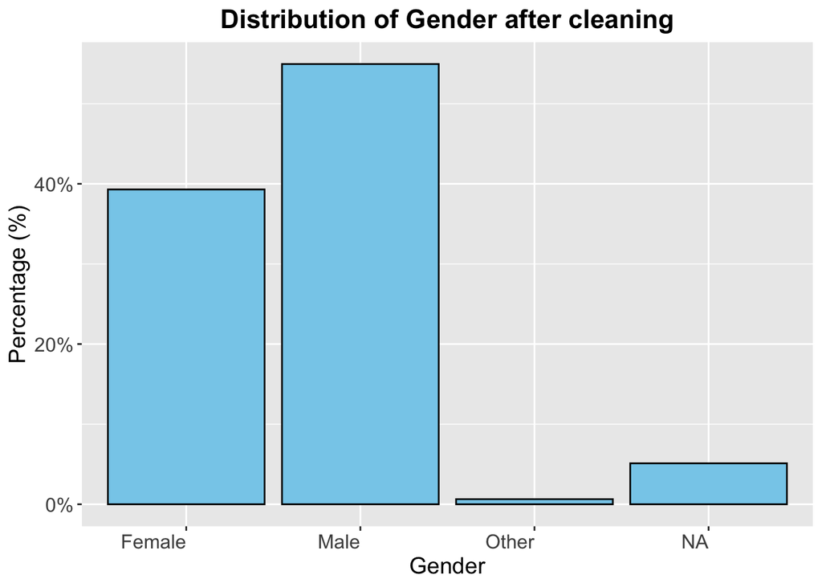

Figure 2: Distribution of Gender after cleaning (%)

```r
# sort(unique(x$gender))
x <- x |>
  mutate(gender = tolower(gender)) |>
  mutate(gender_clean = case_when(
    gender %in% c("male", "m", "man", "boy", "cis male", "heterosexual male") ~ "Male",
    gender %in% c("female", "f", "woman", "girl", "femal", "biological female") ~ "Female",
    gender %in% c("not female", "cisgender") ~ "Other",
    TRUE ~ NA_character_  # Handle any unexpected cases
  ))

ggplot(x, aes(x = gender_clean)) +
  geom_bar(aes(y = (after_stat(count))/sum(after_stat(count))), fill = "skyblue", color = "black") +
  scale_y_continuous(labels = scales::percent_format()) +
  labs(title = "Distribution of Gender after cleaning",
       x = "Gender",
       y = "Percentage (%)") +
  theme_grey() + theme(
    plot.title = element_text(size = 16, face = "bold", hjust = 0.5),
    axis.title = element_text(size = 14),
    axis.text.x = element_text(angle = 0, hjust = 1, size = 12),
    axis.text.y = element_text(size = 12),
    legend.position = "none"  # Hide legend if not necessary
  )
```

## 2.2 Weekly Study Hours

The weekly study hours a few very large outliers - one answered 1500 hours per week (equal to 62.5 days) for this units which suggest a mistype of misunderstanding of the question. These large outliers (> 70 hours) are removed from the dataset.

```r
sort(unique(x$weekly_study_hours))
```

```
 [1]    0    1    2    3    4    5    6    7    8    9   10   12   13   14   15
[16]   16   17   18   19   20   21   24   25   26   28   30   31   32   33   35
[31]   36   38   40   42   45   46   48   50   55   56   60   65   70   80  120
[46]  901 1500
```

When plotting the weekly study hours, we notice that the QQ plots shows a violation of the normality assumption and the histogram shows that the data is skewed with a heavy tail.

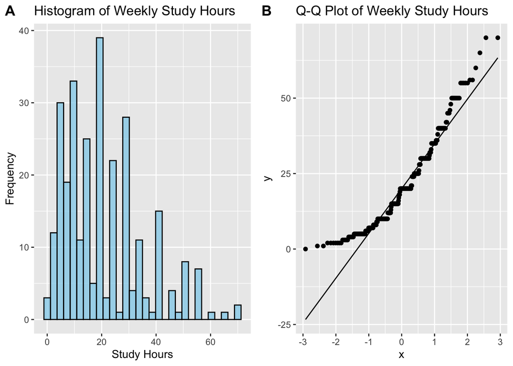

Figure 3: A: Distribution of Weekly Study Hours after cleaning. B: Q-Q plot showing a violation of the normality assumption.

```r
# Remove/cap extreme values
x$weekly_study_hours_cleaned <- ifelse(x$weekly_study_hours > 70, NA, x$weekly_study_hours)

cleaned_hours <- na.omit(x$weekly_study_hours_cleaned)

plot1 <-ggplot(data = data.frame(cleaned_hours), aes(x = cleaned_hours)) +
  geom_histogram(bins = 30, fill = "skyblue", color = "black", alpha = 0.7) +
  labs(title = "Histogram of Weekly Study Hours", x = "Study Hours", y = "Frequency")

# Create a QQ plot to check for normality visually
plot2 <- ggplot(data = data.frame(cleaned_hours), aes(sample = cleaned_hours)) +
  geom_qq() +
  geom_qq_line() +
  labs(title = "Q-Q Plot of Weekly Study Hours")

cowplot::plot_grid(plot1, plot2, labels = "AUTO")
```

## 2.3 Average daily hours of sleep

```r
#sort(unique(x$average_daily_sleep))

# Function to clean and extract numeric values from the average_daily_sleep column
clean_sleep <- function(sleep_str) {
  # Convert to lowercase to handle variations in text
  sleep_str <- tolower(sleep_str)

  # Handle NA values directly
  if (is.na(sleep_str)) {
    return(NA_real_)
  }

  # Handle ranges like "4-5" or "8-10h"
  if (str_detect(sleep_str, "[-~]")) {
    #show(sleep_str)
    numbers <- as.numeric(unlist(str_extract_all(sleep_str, "\\d+\\.?\\d*")))
    #show(numbers)
    return(mean(numbers))
  }

  # Handle hours with minutes (e.g., "7 hours 15 mins.")
  if (str_detect(sleep_str, "hours") & str_detect(sleep_str, "mins")) {
    hours <- as.numeric(str_extract(sleep_str, "\\d+(?=\\s*hours)"))
    mins <- as.numeric(str_extract(sleep_str, "\\d+(?=\\s*mins)"))
    return(hours + mins / 60)
  }

  # Handle minutes only (e.g., "440 minutes")
  if (str_detect(sleep_str, "minutes")) {
    minutes <- as.numeric(str_extract(sleep_str, "\\d+"))
    return(minutes / 60)
  }
  # Handle cases with plain numeric values or hours (e.g., "8", "8h", "7 hours")
  if (str_detect(sleep_str, "^\\d+\\.?\\d*$") | str_detect(sleep_str, "hours?|hrs?|h|hours")) {
    return(as.numeric(str_extract(sleep_str, "\\d+\\.?\\d*")))
  }

  # Handle non-numeric cases (e.g., "Enough", "sleep 10 hours a day")
  if (str_detect(sleep_str, "enough|sleep")) {
    return(NA_real_)
  }

  # Default case: return NA if no other condition is met
  return(NA_real_)
}

# Apply the cleaning function to the average_daily_sleep column
x <- x |>
  mutate(average_daily_sleep_clean = sapply(average_daily_sleep, clean_sleep)) |>
  mutate(average_daily_sleep_clean = round(average_daily_sleep_clean, digits=1))

# Check the unique values after cleaning
#sort(unique(x$average_daily_sleep_clean))
```

## 2.4 Sibling Count

```r
unique(sort(x$sibling_count))
```

```
 [1] "0.0"               "0.5"               "1.0"
 [4] "2 and my dog :)"   "2.0"               "3.0"
 [7] "4.0"               "5.0"               "6.0"
[10] "bicycle"           "I have 2 siblings" "many"
[13] "no"                "none"              "one"
[16] "One"               "Too many"
```

```r
x <- x |>
  mutate(sibling_count_clean = case_when(
    sibling_count %in% c("no", "none") ~ "0.0",
    sibling_count %in% c("I have 2 siblings", "2 and my dog :)") ~ "2.0",
    sibling_count %in% c("one", "One") ~ "1.0",
    sibling_count %in% c("many", "Too many", "bicycle") ~ NA_character_,
    TRUE ~ sibling_count,
    TRUE ~ NA_character_  # Handle any unexpected cases
  ))

x <- x |> mutate(sibling_count_clean = as.integer(sibling_count_clean))
length(x$sibling_count_clean) # 305
```

```
[1] 313
```

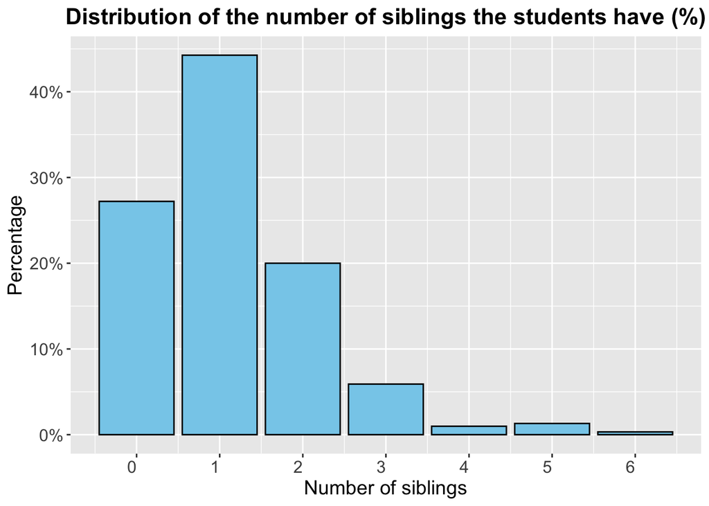

```r
ggplot(x, aes(x = sibling_count_clean)) +
  geom_bar(aes(y = (after_stat(count))/sum(after_stat(count))), fill = "skyblue", color = "black") +
  scale_y_continuous(labels = scales::percent_format()) +
  labs(title = "Distribution of the number of siblings the students have (%)",
       x = "Number of siblings",
       y = "Percentage") +
  scale_x_continuous(breaks = seq(min(x$sibling_count_clean, na.rm = TRUE), max(x$sibling_count_clean, na.rm = TRUE), by = 1)) +
  theme_grey() + theme(
    plot.title = element_text(size = 16, face = "bold", hjust = 0.5),
    axis.title = element_text(size = 14),
    axis.text.x = element_text(angle = 0, hjust = 1, size = 12),
    axis.text.y = element_text(size = 12),
    legend.position = "none"  # Hide legend if not necessary
  )
```

## 2.5 relationship_status

```r
sort(unique(x$relationship_status))
```

```
[1] "I have 2"
[2] "Multiple"
[3] "No"
[4] "No but I would like to have one, please"
[5] "not sure"
[6] "Tears"
[7] "Yes"
```

```r
# Function to clean the relationship_status column
clean_relationship_status <- function(status_str) {
  # Handle NA values directly
  if (is.na(status_str)) {
    return(NA_character_)
  }

  # Convert to lowercase for easier matching
  status_str <- tolower(status_str)

  # Standardize positive relationship statuses
  if (status_str %in% c("yes")) {
    return("Yes")
  }

  # Standardize negative relationship statuses
  if (status_str %in% c("no", "no but i would like to have one, please")) {
    return("No")
  }

  # Handle ambiguous or unclear responses
  if (status_str %in% c("not sure", "tears","i have 2", "multiple")) {
    return(NA_character_)
  }

  # Default case: return NA for any other invalid inputs
  return(NA_character_)
}

# Apply the cleaning function to the relationship_status column
x <- x |>
  mutate(relationship_status_clean = sapply(relationship_status, clean_relationship_status))

# Check the unique values after cleaning
sort(unique(x$relationship_status_clean))
```

```
[1] "No"  "Yes"
```

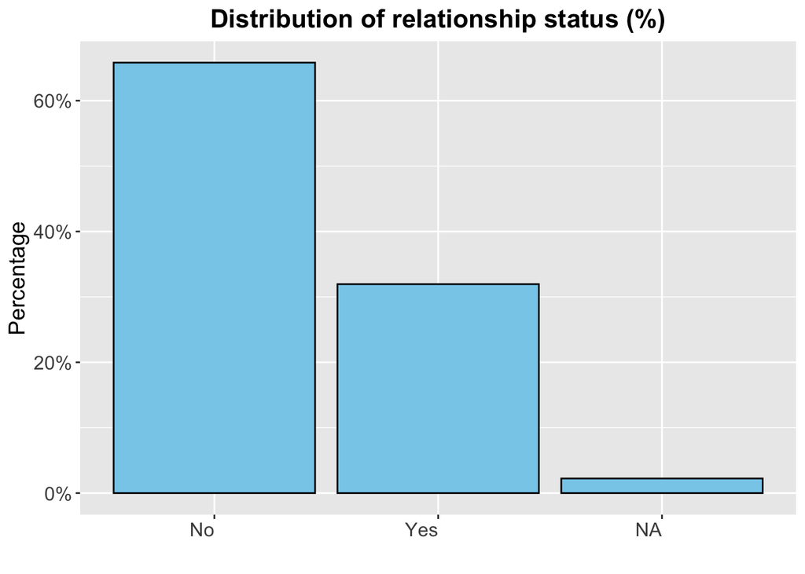

```r
ggplot(x, aes(x = relationship_status_clean)) +
  geom_bar(aes(y = (after_stat(count))/sum(after_stat(count))), fill = "skyblue", color = "black") +
  scale_y_continuous(labels = scales::percent_format()) +
  labs(title = "Distribution of relationship status (%)",
       x = "",
       y = "Percentage") +
  theme_grey() + theme(
    plot.title = element_text(size = 16, face = "bold", hjust = 0.5),
    axis.title = element_text(size = 14),
    axis.text.x = element_text(angle = 0, hjust = 1, size = 12),
    axis.text.y = element_text(size = 12),
    legend.position = "none"  # Hide legend if not necessary
  )
```

## 2.6 Social Media platforms

```r
x |> janitor::tabyl(social_media) |>
  gt::gt() |>
  gt::fmt_percent(columns = 3:4, decimals = 1) |>
  gt::cols_label(social_media = "Favourite social media platform")
```

| Favourite social media platform | n | percent | valid_percent |
| --- | --- | --- | --- |
| Bilibili | 3 | 1.0% | 1.0% |
| Canvas | 1 | 0.3% | 0.3% |
| Discord | 10 | 3.2% | 3.3% |
| Don't use social media | 1 | 0.3% | 0.3% |
| Ed Discussion | 1 | 0.3% | 0.3% |
| FaceTime | 1 | 0.3% | 0.3% |
| Facebook | 3 | 1.0% | 1.0% |
| IG | 2 | 0.6% | 0.7% |
| Insta | 1 | 0.3% | 0.3% |
| Instagam | 1 | 0.3% | 0.3% |
| Instagram | 75 | 24.0% | 25.1% |
| Instagram (reels) | 1 | 0.3% | 0.3% |
| Instagram,Wechat | 1 | 0.3% | 0.3% |
| Instgram | 1 | 0.3% | 0.3% |
| Line | 1 | 0.3% | 0.3% |
| Little redbook | 1 | 0.3% | 0.3% |
| Mastodon | 1 | 0.3% | 0.3% |
| Miiverse | 1 | 0.3% | 0.3% |
| NA | 1 | 0.3% | 0.3% |
| None | 1 | 0.3% | 0.3% |
| Pinterest | 2 | 0.6% | 0.7% |
| QQ | 1 | 0.3% | 0.3% |
| Reddit | 2 | 0.6% | 0.7% |
| Snapchat | 1 | 0.3% | 0.3% |
| TIKTOK | 2 | 0.6% | 0.7% |
| Tik Tok | 2 | 0.6% | 0.7% |
| Tik tok | 1 | 0.3% | 0.3% |
| TikTok | 11 | 3.5% | 3.7% |
| Tiktok | 11 | 3.5% | 3.7% |
| Travel | 1 | 0.3% | 0.3% |
| Twitter | 5 | 1.6% | 1.7% |
| Twitter/X | 1 | 0.3% | 0.3% |
| WeChat | 3 | 1.0% | 1.0% |
| Wechat | 12 | 3.8% | 4.0% |
| WhatsApp | 3 | 1.0% | 1.0% |
| Whatsapp | 2 | 0.6% | 0.7% |
| X | 4 | 1.3% | 1.3% |
| Xiaohongshu | 1 | 0.3% | 0.3% |
| YouTube | 6 | 1.9% | 2.0% |
| Youtube | 10 | 3.2% | 3.3% |
| Youtube / Instagram | 1 | 0.3% | 0.3% |
| bilibili | 7 | 2.2% | 2.3% |
| canvas | 1 | 0.3% | 0.3% |
| discord | 1 | 0.3% | 0.3% |
| douyin | 1 | 0.3% | 0.3% |
| edstem | 1 | 0.3% | 0.3% |
| facebook | 2 | 0.6% | 0.7% |
| hmm... not sure | 1 | 0.3% | 0.3% |
| iMessage | 1 | 0.3% | 0.3% |
| iMessages | 1 | 0.3% | 0.3% |
| ig | 1 | 0.3% | 0.3% |
| ins | 4 | 1.3% | 1.3% |
| insta | 4 | 1.3% | 1.3% |
| instagram | 32 | 10.2% | 10.7% |
| little red book | 2 | 0.6% | 0.7% |
| n | 1 | 0.3% | 0.3% |
| n/a | 1 | 0.3% | 0.3% |
| redbook/ ig | 1 | 0.3% | 0.3% |
| reddit | 1 | 0.3% | 0.3% |
| snapchat | 1 | 0.3% | 0.3% |
| steam | 1 | 0.3% | 0.3% |
| strava | 1 | 0.3% | 0.3% |
| ticktock | 1 | 0.3% | 0.3% |
| ticktok | 1 | 0.3% | 0.3% |
| tik tok | 2 | 0.6% | 0.7% |
| tiktok | 11 | 3.5% | 3.7% |
| twitter | 1 | 0.3% | 0.3% |
| wechat | 14 | 4.5% | 4.7% |
| weibo | 1 | 0.3% | 0.3% |
| weibo and xiaohongshu | 1 | 0.3% | 0.3% |
| whatsapp | 1 | 0.3% | 0.3% |
| x | 1 | 0.3% | 0.3% |
| xiaohongshu | 2 | 0.6% | 0.7% |
| youtube | 7 | 2.2% | 2.3% |
| NA | 14 | 4.5% | NA |

```r
x= x |> mutate(
  social_media_clean = tolower(social_media),
  social_media_clean = str_replace_all(social_media_clean, '[[:punct:]]',' '),
  social_media_clean = stringr::word(social_media_clean),
  social_media_clean = case_when(
    stringr::str_starts(social_media_clean,"in") ~ "instagram",
    stringr::str_starts(social_media_clean,"ig") ~ "instagram",
    stringr::str_starts(social_media_clean,"tik") ~ "tiktok",
    stringr::str_starts(social_media_clean,"we") ~ "wechat",
    stringr::str_starts(social_media_clean,"twi") ~ "twitter",
    stringr::str_starts(social_media_clean,"x") ~ "twitter",
    stringr::str_starts(social_media_clean,"mess") ~ "facebook",
    stringr::str_starts(social_media_clean,"bil") ~ "bilibili",
    is.na(social_media_clean) ~ "none",
    TRUE ~ social_media_clean
  ),
  social_media_clean = tools::toTitleCase(social_media_clean),
  social_media_clean = forcats::fct_lump_min(social_media_clean, min = 10)
)
```

```r
x |> janitor::tabyl(social_media_clean) |>
  arrange(desc(n)) |>
  gt::gt() |>
  gt::fmt_percent(columns = 3, decimals = 1) |>
  gt::cols_label(social_media_clean = "Favourite social media platform") |>
  gt::cols_align(align = "left", columns = 1)
```

| Favourite social media platform | n | percent |
| --- | --- | --- |
| Instagram | 123 | 39.3% |
| Other | 44 | 14.1% |
| Tiktok | 40 | 12.8% |
| Wechat | 31 | 9.9% |
| Youtube | 24 | 7.7% |
| None | 15 | 4.8% |
| Twitter | 15 | 4.8% |
| Discord | 11 | 3.5% |
| Bilibili | 10 | 3.2% |

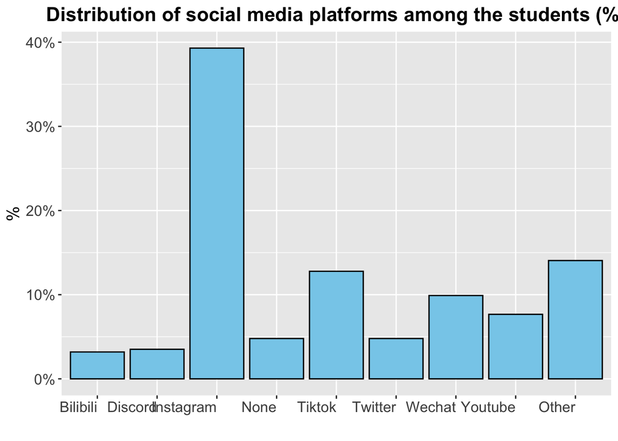

```r
#sort(unique(x$social_media_clean))
ggplot(x, aes(x = social_media_clean)) +
  geom_bar(aes(y = (after_stat(count))/sum(after_stat(count))), fill = "skyblue", color = "black") +
  scale_y_continuous(labels = scales::percent_format()) +
  labs(title = "Distribution of social media platforms among the students (%)",
       x = "",
       y = "%") +
  theme_grey() + theme(
    plot.title = element_text(size = 16, face = "bold", hjust = 0.5),
    axis.title = element_text(size = 14),
    axis.text.x = element_text(angle = 0, hjust = 1, size = 12),
    axis.text.y = element_text(size = 12),
    legend.position = "none"  # Hide legend if not necessary
  )
```

## 2.7 target_grade

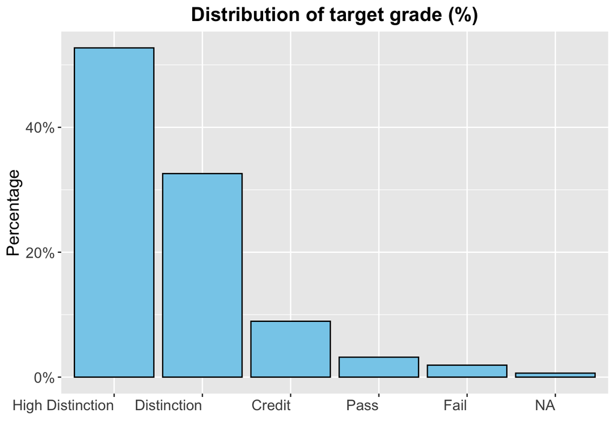

```r
x <- x |> mutate(target_grade = factor(target_grade,
                             levels = c("High Distinction", "Distinction", "Credit", "Pass", "Fail", NA)))

ggplot(x, aes(x = target_grade)) +
  geom_bar(aes(y = (after_stat(count))/sum(after_stat(count))), fill = "skyblue", color = "black") +
  scale_y_continuous(labels = scales::percent_format()) +
  labs(title = "Distribution of target grade (%)",
       x = "",
       y = "Percentage") +
  theme_grey() + theme(
    plot.title = element_text(size = 16, face = "bold", hjust = 0.5),
    axis.title = element_text(size = 14),
    axis.text.x = element_text(angle = 0, hjust = 1, size = 12),
    axis.text.y = element_text(size = 12),
    legend.position = "none"  # Hide legend if not necessary
  )
```

# 3 Tests and results

## 3.1 Is there an association between the number of siblings a student has and their relationship status?

To investigate whether there is an association between the number of siblings (`sibling_count_clean`) and relationship status (`relationship_status_clean`) we will perform a Chi-Square test of independence. This test is appropriate as both variables are categorical.

The contingency table below shows the observed counts of students categorized by the number of siblings they have and their relationship status. Given the values in the table, where some cells have counts less than 5, the sample size assumption for the Chi-Square test of independence is violated. Thus we need to combine some of the categories.

```r
table(x$relationship_status_clean,x$sibling_count_clean)
```

```
       0  1  2  3  4  5  6
  No  61 81 41 12  1  4  1
  Yes 22 50 18  6  2  0  0
```

```r
x <- x %>%
  mutate(sibling_group = case_when(
    sibling_count_clean %in% c("3", "4", "5", "6") ~ "3+",
    TRUE ~ as.character(sibling_count_clean)
  )) |> mutate(sibling_group = factor(sibling_group,
                             levels = c("0","1", "2", "3+" ,NA)))

# Print the updated table to see the changes
# table(x$sibling_group)

# Create new contingency table with combined categories
tabl<- table(x$relationship_status_clean, x$sibling_group)
tabl
```

```
       0  1  2 3+
  No  61 81 41 18
  Yes 22 50 18  8
```

```r
# Perform Chi-Square Test
chisq.test(tabl, correct=FALSE)
```

```
    Pearson's Chi-squared test

data:  tabl
X-squared = 3.3947, df = 3, p-value = 0.3347
```